# Coursera Data Science Specialization : Capstone Project

Suman Adhikari  
Nov-27-2017

### The Capstone Project

The Objective of this project was to develop a text prediction model and deploy the model via shiny app, which predicts the next possible words based on the user input words.

Presentation highlights:

- Methodology used in developing Algorithm
- Alogorithm response time and accuracy
- Shiny app manual

### Data, Alogrithm and Models

- The data used for bulding model was obtained from [Capstone Dataset](https://d396qusza40orc.cloudfront.net/dsscapstone/dataset/Coursera-SwiftKey.zip)
- The data was sampled randomly to sample size of 10% of toatl data size and sample data was divided in to 80% training and 20% testing data.
- Sample Data was cleaned, lower-cased, removing links, twitter handles, punctuations, numbers and extra whitespaces etc..
- N-gram (2,3,4) were modeled for both respective traning and test sets.
- Perplexity for each model was measured against test data set with fourgram having low perplexity.

### Data, Alogrithm and Models contd..

- N-gram model with stupid back-off strategy was used for final prediction algorithm.
  - i.e take n-gram input and search in (n+1)-gram model if no match found backoff to n-gram model, similar approach is carried out until a match is found and if still no match found, retrun top unigram words.
- Various methods of improving the prediction accuracy and speed were explored e.g removing terms with count < 2, splitting joined words and was average worst response time to 1.5 sec.

### Data Product : Shiny App manual

The shiny app interface for data products can be reached via : [Shiny App](https://dralmostright.shinyapps.io/data_science_capstone_project_shiny_app/)

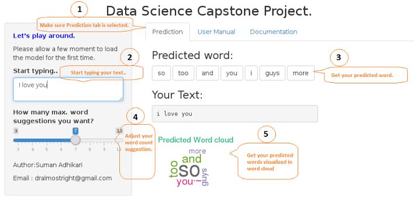